# Data Transformation Day 2

## Modifying Factor Levels

Here’s a count of the levels in party_id

```r
df %>% count(partyid)
```

```
## # A tibble: 10 × 2
##    partyid                n
##    <fct>              <int>
##  1 No answer            154
##  2 Don't know             1
##  3 Other party          393
##  4 Strong republican   2314
##  5 Not str republican  3032
##  6 Ind,near rep        1791
##  7 Independent         4119
##  8 Ind,near dem        2499
##  9 Not str democrat    3690
## 10 Strong democrat     3490
```

`fct_recode` let’s us rename variables (new varname left = old varname right)

```r
df %>%
  mutate(partyid = fct_recode(partyid,
                              "Republican, strong"    = "Strong republican",
                              "Republican, weak"      = "Not str republican",
                              "Independent, near rep" = "Ind,near rep",
                              "Independent, near dem" = "Ind,near dem",
                              "Democrat, weak"        = "Not str democrat",
                              "Democrat, strong"      = "Strong democrat"
  )) %>%
  count(partyid) #Count party ID
```

```
## # A tibble: 10 × 2
##    partyid                   n
##    <fct>                 <int>
##  1 No answer               154
##  2 Don't know                1
##  3 Other party             393
##  4 Republican, strong     2314
##  5 Republican, weak       3032
##  6 Independent, near rep  1791
##  7 Independent            4119
##  8 Independent, near dem  2499
##  9 Democrat, weak         3690
## 10 Democrat, strong       3490
```

`fct_recode()` will leave levels that aren’t explicitly mentioned as is, and will warn you if you accidentally refer to a level that doesn’t exist.

If you want to collapse a lot of levels, `fct_collapse()` is a useful variant of `fct_recode()`. For each new variable, you can provide a vector of old levels:

```r
df %>%
  mutate(partyid = fct_collapse(partyid,
                                other = c("No answer", "Don't know", "Other party"),
                                rep = c("Strong republican", "Not str republican"),
                                ind = c("Ind,near rep", "Independent", "Ind,near dem"),
                                dem = c("Not str democrat", "Strong democrat")
  )) %>%
  count(partyid)
```

```
## # A tibble: 4 × 2
##   partyid     n
##   <fct>   <int>
## 1 other     548
## 2 rep      5346
## 3 ind      8409
## 4 dem      7180
```

Pretty cool huh?! We just created in groupings to plot or do analyses on.

Sometimes you just want to lump together all the small groups to make a plot or table simpler. That’s the job of `fct_lump()`

```r
df %>%
  count(relig) #This is before lumping
```

```
## # A tibble: 15 × 2
##    relig                       n
##    <fct>                   <int>
##  1 No answer                  93
##  2 Don't know                 15
##  3 Inter-nondenominational   109
##  4 Native american            23
##  5 Christian                 689
##  6 Orthodox-christian         95
##  7 Moslem/islam              104
##  8 Other eastern              32
##  9 Hinduism                   71
## 10 Buddhism                  147
## 11 Other                     224
## 12 None                     3523
## 13 Jewish                    388
## 14 Catholic                 5124
## 15 Protestant              10846
```

```r
df %>%
  mutate(marital = fct_lump(marital)) %>%
  count(marital)
```

```
## # A tibble: 4 × 2
##   marital           n
##   <fct>         <int>
## 1 Never married  5416
## 2 Divorced       3383
## 3 Married       10117
## 4 Other          2567
```

```r
df %>%
  mutate(relig = fct_lump(relig)) %>%
  count(relig) #This is default after lumping
```

```
## # A tibble: 2 × 2
##   relig          n
##   <fct>      <int>
## 1 Protestant 10846
## 2 Other      10637
```

```r
levels(df$relig)
```

```
##  [1] "No answer"               "Don't know"
##  [3] "Inter-nondenominational" "Native american"
##  [5] "Christian"               "Orthodox-christian"
##  [7] "Moslem/islam"            "Other eastern"
##  [9] "Hinduism"                "Buddhism"
## [11] "Other"                   "None"
## [13] "Jewish"                  "Catholic"
## [15] "Protestant"              "Not applicable"
```

You can collapse across specified lumps…

```r
df %>%
  mutate(relig = fct_lump(relig, n = 10)) %>% #Specify lumps here
  count(relig, sort = TRUE)
```

```
## # A tibble: 10 × 2
##    relig                       n
##    <fct>                   <int>
##  1 Protestant              10846
##  2 Catholic                 5124
##  3 None                     3523
##  4 Christian                 689
##  5 Other                     458
##  6 Jewish                    388
##  7 Buddhism                  147
##  8 Inter-nondenominational   109
##  9 Moslem/islam              104
## 10 Orthodox-christian         95
```

## Play time

Answer some interesting questions about this dataset

```r
df
```

```
## # A tibble: 21,483 × 9
##     year marital         age race  rincome        partyid    relig denom tvhours
##    <int> <fct>         <int> <fct> <fct>          <fct>      <fct> <fct>   <int>
##  1  2000 Never married    26 White $8000 to 9999  Ind,near … Prot… Sout…      12
##  2  2000 Divorced         48 White $8000 to 9999  Not str r… Prot… Bapt…      NA
##  3  2000 Widowed          67 White Not applicable Independe… Prot… No d…       2
##  4  2000 Never married    39 White Not applicable Ind,near … Orth… Not …       4
##  5  2000 Divorced         25 White Not applicable Not str d… None  Not …       1
##  6  2000 Married          25 White $20000 - 24999 Strong de… Prot… Sout…      NA
##  7  2000 Never married    36 White $25000 or more Not str r… Chri… Not …       3
##  8  2000 Divorced         44 White $7000 to 7999  Ind,near … Prot… Luth…      NA
##  9  2000 Married          44 White $25000 or more Not str d… Prot… Other       0
## 10  2000 Married          47 White $25000 or more Strong re… Prot… Sout…       3
## # … with 21,473 more rows
```

What is the proportion of race in each religion?

```r
df %>%
  group_by(relig) %>%
  count(...) %>%
  mutate(prop = ...)
```

Try to plot it

```r
df %>%
  group_by(relig) %>%
  count(race) %>%
  mutate(prop = n/sum(n)) %>%
  ggplot(aes(relig, ..., fill = ...)) +
  geom_bar(stat = "...", position = "...") +
  theme(...)
```

## Solutions

Play 1

```r
View(df %>%
  group_by(relig) %>%
  count(race) %>%
  mutate(prop = n/sum(n)))
```

Play 2

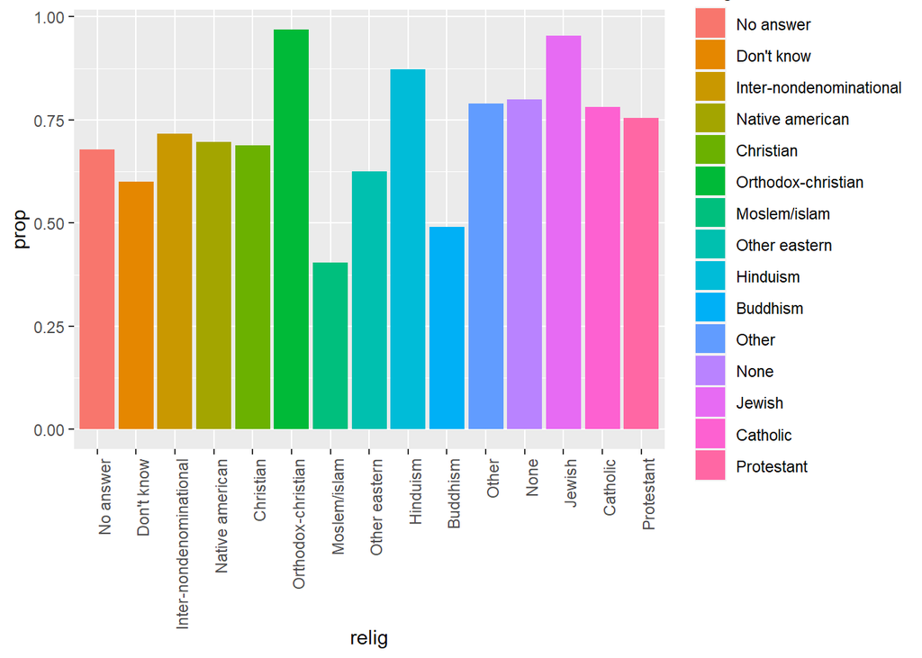

```r
df %>%
  group_by(relig) %>%
  count(race) %>%
  mutate(prop = n/sum(n)) %>%
  ggplot(mapping = aes(relig, prop, fill = relig)) +
  geom_bar(stat = "identity", position = "dodge") +
  theme(axis.text.x = element_text(angle = 90, hjust = 1))
```

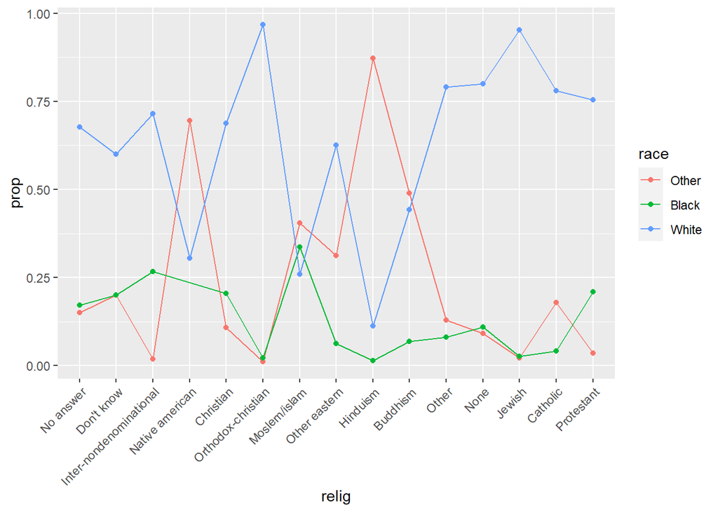

```r
df %>%
  group_by(relig) %>%
  count(race) %>%
  mutate(prop = n/sum(n)) %>%
  ggplot(mapping = aes(x = relig, y = prop, color = race)) +
  geom_line(aes(group = race)) + geom_point() +
  theme(axis.text.x = element_text(angle = 45, hjust = 1))
```

```r
df %>%
  count(relig, race) %>%
  group_by(relig) %>%
  mutate(prop = n/sum(n))
```

```
## # A tibble: 44 × 4
## # Groups:   relig [15]
##    relig                   race      n   prop
##    <fct>                   <fct> <int>  <dbl>
##  1 No answer               Other    14 0.151
##  2 No answer               Black    16 0.172
##  3 No answer               White    63 0.677
##  4 Don't know              Other     3 0.2
##  5 Don't know              Black     3 0.2
##  6 Don't know              White     9 0.6
##  7 Inter-nondenominational Other     2 0.0183
##  8 Inter-nondenominational Black    29 0.266
##  9 Inter-nondenominational White    78 0.716
## 10 Native american         Other    16 0.696
## # … with 34 more rows
```